# Risk Factor Analysis

## Outcome Variable

**Outcome Variable:** stunted

## Predictor Variables

**Intervention Variable:** birthwtXexclfeed6

**Adjustment Set:**

- arm
- sex
- W_mage
- meducyrs
- feducyrs
- hhwealth_quart
- hfoodsec
- vagbrth
- W_nrooms
- W_nchldlt5
- brthmon
- W_parity
- impfloor
- impsan
- safeh20
- delta_W_mage
- delta_meducyrs
- delta_feducyrs
- delta_hhwealth_quart
- delta_hfoodsec
- delta_vagbrth
- delta_W_nrooms
- delta_W_nchldlt5
- delta_brthmon
- delta_W_parity
- delta_impfloor
- delta_impsan
- delta_safeh20

## Stratifying Variables

The analysis was stratified on these variable(s):

- agecat
- studyid
- country

## Data Summary

| agecat | studyid | country | birthwtXexclfeed6 | stunted | n_cell | n |
| --- | --- | --- | --- | --- | --- | --- |
| 24 months | ki0047075b-MAL-ED | BANGLADESH | Normal or high birthweight X EBF | 0 | 21 | 205 |
| 24 months | ki0047075b-MAL-ED | BANGLADESH | Normal or high birthweight X EBF | 1 | 20 | 205 |
| 24 months | ki0047075b-MAL-ED | BANGLADESH | Low birth weight X EBF | 0 | 5 | 205 |
| 24 months | ki0047075b-MAL-ED | BANGLADESH | Low birth weight X EBF | 1 | 7 | 205 |
| 24 months | ki0047075b-MAL-ED | BANGLADESH | Normal or high birthweight X No EBF | 0 | 74 | 205 |
| 24 months | ki0047075b-MAL-ED | BANGLADESH | Normal or high birthweight X No EBF | 1 | 47 | 205 |
| 24 months | ki0047075b-MAL-ED | BANGLADESH | Low birth weight X No EBF | 0 | 11 | 205 |
| 24 months | ki0047075b-MAL-ED | BANGLADESH | Low birth weight X No EBF | 1 | 20 | 205 |
| 24 months | ki0047075b-MAL-ED | BRAZIL | Normal or high birthweight X EBF | 0 | 13 | 169 |
| 24 months | ki0047075b-MAL-ED | BRAZIL | Normal or high birthweight X EBF | 1 | 0 | 169 |
| 24 months | ki0047075b-MAL-ED | BRAZIL | Low birth weight X EBF | 0 | 2 | 169 |
| 24 months | ki0047075b-MAL-ED | BRAZIL | Low birth weight X EBF | 1 | 0 | 169 |
| 24 months | ki0047075b-MAL-ED | BRAZIL | Normal or high birthweight X No EBF | 0 | 142 | 169 |
| 24 months | ki0047075b-MAL-ED | BRAZIL | Normal or high birthweight X No EBF | 1 | 6 | 169 |
| 24 months | ki0047075b-MAL-ED | BRAZIL | Low birth weight X No EBF | 0 | 6 | 169 |
| 24 months | ki0047075b-MAL-ED | BRAZIL | Low birth weight X No EBF | 1 | 0 | 169 |
| 24 months | ki0047075b-MAL-ED | INDIA | Normal or high birthweight X EBF | 0 | 1 | 217 |
| 24 months | ki0047075b-MAL-ED | INDIA | Normal or high birthweight X EBF | 1 | 4 | 217 |
| 24 months | ki0047075b-MAL-ED | INDIA | Low birth weight X EBF | 0 | 0 | 217 |
| 24 months | ki0047075b-MAL-ED | INDIA | Low birth weight X EBF | 1 | 0 | 217 |
| 24 months | ki0047075b-MAL-ED | INDIA | Normal or high birthweight X No EBF | 0 | 109 | 217 |
| 24 months | ki0047075b-MAL-ED | INDIA | Normal or high birthweight X No EBF | 1 | 69 | 217 |
| 24 months | ki0047075b-MAL-ED | INDIA | Low birth weight X No EBF | 0 | 17 | 217 |
| 24 months | ki0047075b-MAL-ED | INDIA | Low birth weight X No EBF | 1 | 17 | 217 |
| 24 months | ki0047075b-MAL-ED | NEPAL | Normal or high birthweight X EBF | 0 | 12 | 220 |
| 24 months | ki0047075b-MAL-ED | NEPAL | Normal or high birthweight X EBF | 1 | 2 | 220 |
| 24 months | ki0047075b-MAL-ED | NEPAL | Low birth weight X EBF | 0 | 0 | 220 |
| 24 months | ki0047075b-MAL-ED | NEPAL | Low birth weight X EBF | 1 | 0 | 220 |
| 24 months | ki0047075b-MAL-ED | NEPAL | Normal or high birthweight X No EBF | 0 | 152 | 220 |
| 24 months | ki0047075b-MAL-ED | NEPAL | Normal or high birthweight X No EBF | 1 | 34 | 220 |

[output cut: 194 more lines]

The following strata were considered:

- agecat: 24 months, studyid: ki0047075b-MAL-ED, country: BANGLADESH
- agecat: 24 months, studyid: ki0047075b-MAL-ED, country: BRAZIL
- agecat: 24 months, studyid: ki0047075b-MAL-ED, country: INDIA
- agecat: 24 months, studyid: ki0047075b-MAL-ED, country: NEPAL
- agecat: 24 months, studyid: ki0047075b-MAL-ED, country: PERU
- agecat: 24 months, studyid: ki0047075b-MAL-ED, country: SOUTH AFRICA
- agecat: 24 months, studyid: ki0047075b-MAL-ED, country: TANZANIA, UNITED REPUBLIC OF
- agecat: 24 months, studyid: ki1000108-CMC-V-BCS-2002, country: INDIA
- agecat: 24 months, studyid: ki1000108-IRC, country: INDIA
- agecat: 24 months, studyid: ki1017093b-PROVIDE, country: BANGLADESH
- agecat: 24 months, studyid: ki1101329-Keneba, country: GAMBIA
- agecat: 24 months, studyid: kiGH5241-JiVitA-3, country: BANGLADESH
- agecat: 24 months, studyid: kiGH5241-JiVitA-4, country: BANGLADESH
- agecat: 6 months, studyid: ki0047075b-MAL-ED, country: BANGLADESH
- agecat: 6 months, studyid: ki0047075b-MAL-ED, country: BRAZIL
- agecat: 6 months, studyid: ki0047075b-MAL-ED, country: INDIA
- agecat: 6 months, studyid: ki0047075b-MAL-ED, country: NEPAL
- agecat: 6 months, studyid: ki0047075b-MAL-ED, country: PERU
- agecat: 6 months, studyid: ki0047075b-MAL-ED, country: SOUTH AFRICA
- agecat: 6 months, studyid: ki0047075b-MAL-ED, country: TANZANIA, UNITED REPUBLIC OF
- agecat: 6 months, studyid: ki1000108-CMC-V-BCS-2002, country: INDIA
- agecat: 6 months, studyid: ki1000108-IRC, country: INDIA
- agecat: 6 months, studyid: ki1000109-EE, country: PAKISTAN
- agecat: 6 months, studyid: ki1000304b-SAS-CompFeed, country: INDIA
- agecat: 6 months, studyid: ki1017093b-PROVIDE, country: BANGLADESH
- agecat: 6 months, studyid: ki1101329-Keneba, country: GAMBIA
- agecat: 6 months, studyid: kiGH5241-JiVitA-3, country: BANGLADESH
- agecat: 6 months, studyid: kiGH5241-JiVitA-4, country: BANGLADESH

### Dropped Strata

Some strata were dropped due to rare outcomes:

- agecat: 24 months, studyid: ki0047075b-MAL-ED, country: BRAZIL
- agecat: 24 months, studyid: ki0047075b-MAL-ED, country: INDIA
- agecat: 24 months, studyid: ki0047075b-MAL-ED, country: NEPAL
- agecat: 24 months, studyid: ki0047075b-MAL-ED, country: PERU
- agecat: 24 months, studyid: ki0047075b-MAL-ED, country: SOUTH AFRICA
- agecat: 24 months, studyid: ki0047075b-MAL-ED, country: TANZANIA, UNITED REPUBLIC OF
- agecat: 24 months, studyid: ki1000108-CMC-V-BCS-2002, country: INDIA
- agecat: 24 months, studyid: ki1000108-IRC, country: INDIA
- agecat: 6 months, studyid: ki0047075b-MAL-ED, country: BRAZIL
- agecat: 6 months, studyid: ki0047075b-MAL-ED, country: INDIA
- agecat: 6 months, studyid: ki0047075b-MAL-ED, country: NEPAL
- agecat: 6 months, studyid: ki0047075b-MAL-ED, country: PERU
- agecat: 6 months, studyid: ki0047075b-MAL-ED, country: SOUTH AFRICA
- agecat: 6 months, studyid: ki0047075b-MAL-ED, country: TANZANIA, UNITED REPUBLIC OF
- agecat: 6 months, studyid: ki1000108-CMC-V-BCS-2002, country: INDIA
- agecat: 6 months, studyid: ki1000108-IRC, country: INDIA
- agecat: 6 months, studyid: ki1000304b-SAS-CompFeed, country: INDIA

## Methods Detail

We’re interested in the causal parameters $E[Y_a]$ for all values of $a \in \mathcal{A}$. These parameters represent the mean outcome if, possibly contrary to fact, we intervened to set all units to have $A=a$. Under the randomization and positivity assumptions, these are identified by the statistical parameters $\psi_a=E_W[E_{Y|A,W}(Y|A=a,W)]$. In addition, we’re interested in the mean of $Y$, $E[Y]$ under no intervention (the observed mean). We will estimate these parameters by using SuperLearner to fit the relevant likelihood factors – $E_{Y|A,W}(Y|A=a,W)$ and $p(A=a|W)$, and then updating our likelihood fit using a joint TMLE.

For unadjusted analyses ($W=\{\}$), initial likelihoods were estimated using Lrnr_glm to estimate the simple $E(Y|A)$ and Lrnr_mean to estimate $p(A)$. For adjusted analyses, a small library containing Lrnr_glmnet, Lrnr_xgboost, and Lrnr_mean was used.

Having estimated these parameters, we will then use the delta method to estimate relative risks and attributable risks relative to a prespecified baseline level of $A$.

# Results Detail

## Results Plots

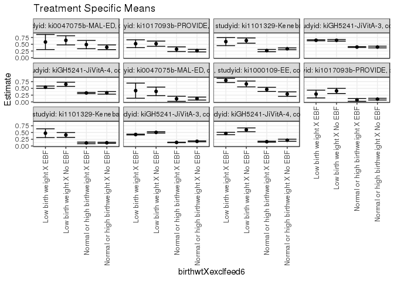

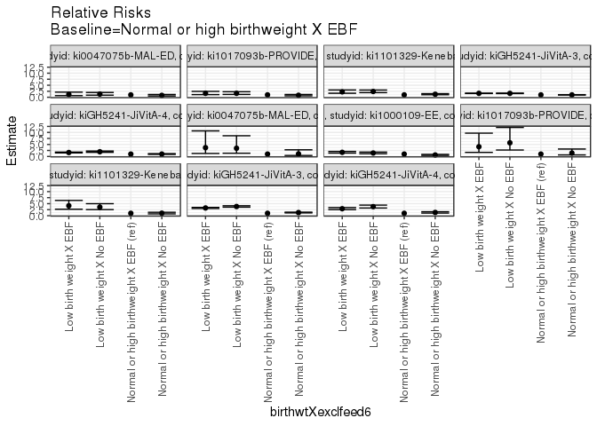

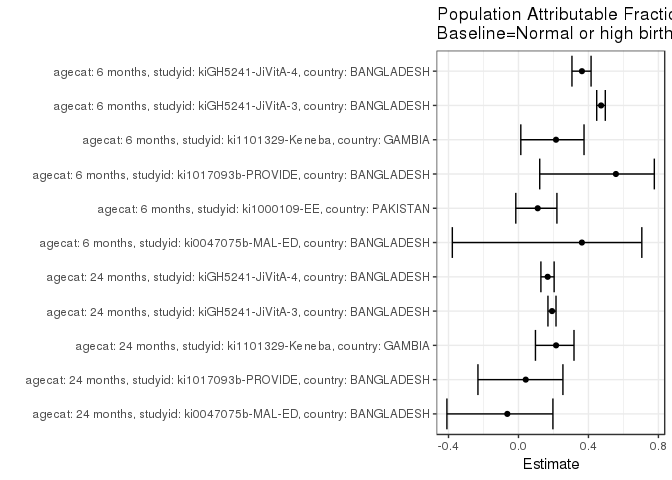

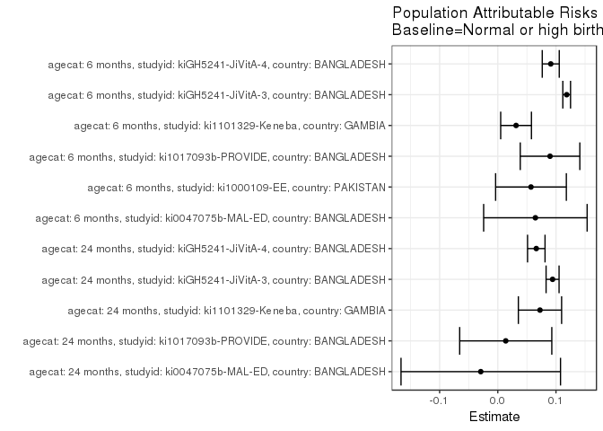

## Results Table

### Parameter: TSM

| agecat | studyid | country | intervention_level | baseline_level | estimate | ci_lower | ci_upper |
| --- | --- | --- | --- | --- | --- | --- | --- |
| 24 months | ki0047075b-MAL-ED | BANGLADESH | Normal or high birthweight X EBF | NA | 0.4878049 | 0.3344284 | 0.6411814 |
| 24 months | ki0047075b-MAL-ED | BANGLADESH | Low birth weight X EBF | NA | 0.5833333 | 0.3037108 | 0.8629558 |
| 24 months | ki0047075b-MAL-ED | BANGLADESH | Normal or high birthweight X No EBF | NA | 0.3884298 | 0.3013742 | 0.4754853 |
| 24 months | ki0047075b-MAL-ED | BANGLADESH | Low birth weight X No EBF | NA | 0.6451613 | 0.4763200 | 0.8140026 |
| 24 months | ki1017093b-PROVIDE | BANGLADESH | Normal or high birthweight X EBF | NA | 0.3156262 | 0.2283463 | 0.4029062 |
| 24 months | ki1017093b-PROVIDE | BANGLADESH | Low birth weight X EBF | NA | 0.5198494 | 0.3743519 | 0.6653468 |
| 24 months | ki1017093b-PROVIDE | BANGLADESH | Normal or high birthweight X No EBF | NA | 0.2628066 | 0.2155033 | 0.3101100 |
| 24 months | ki1017093b-PROVIDE | BANGLADESH | Low birth weight X No EBF | NA | 0.5200928 | 0.4233847 | 0.6168009 |
| 24 months | ki1101329-Keneba | GAMBIA | Normal or high birthweight X EBF | NA | 0.2648888 | 0.2217553 | 0.3080223 |
| 24 months | ki1101329-Keneba | GAMBIA | Low birth weight X EBF | NA | 0.5974537 | 0.4482740 | 0.7466334 |
| 24 months | ki1101329-Keneba | GAMBIA | Normal or high birthweight X No EBF | NA | 0.3324695 | 0.2998244 | 0.3651145 |
| 24 months | ki1101329-Keneba | GAMBIA | Low birth weight X No EBF | NA | 0.6371923 | 0.5400602 | 0.7343244 |
| 24 months | kiGH5241-JiVitA-3 | BANGLADESH | Normal or high birthweight X EBF | NA | 0.3966358 | 0.3797965 | 0.4134750 |
| 24 months | kiGH5241-JiVitA-3 | BANGLADESH | Low birth weight X EBF | NA | 0.6482271 | 0.6283667 | 0.6680875 |
| 24 months | kiGH5241-JiVitA-3 | BANGLADESH | Normal or high birthweight X No EBF | NA | 0.3968704 | 0.3660442 | 0.4276965 |
| 24 months | kiGH5241-JiVitA-3 | BANGLADESH | Low birth weight X No EBF | NA | 0.6453823 | 0.6156199 | 0.6751447 |
| 24 months | kiGH5241-JiVitA-4 | BANGLADESH | Normal or high birthweight X EBF | NA | 0.3303289 | 0.3071773 | 0.3534805 |
| 24 months | kiGH5241-JiVitA-4 | BANGLADESH | Low birth weight X EBF | NA | 0.5436310 | 0.5018446 | 0.5854174 |
| 24 months | kiGH5241-JiVitA-4 | BANGLADESH | Normal or high birthweight X No EBF | NA | 0.3343800 | 0.2872463 | 0.3815138 |
| 24 months | kiGH5241-JiVitA-4 | BANGLADESH | Low birth weight X No EBF | NA | 0.6513830 | 0.5740859 | 0.7286800 |
| 6 months | ki0047075b-MAL-ED | BANGLADESH | Normal or high birthweight X EBF | NA | 0.1136364 | 0.0196570 | 0.2076157 |
| 6 months | ki0047075b-MAL-ED | BANGLADESH | Low birth weight X EBF | NA | 0.4166667 | 0.1371186 | 0.6962147 |
| 6 months | ki0047075b-MAL-ED | BANGLADESH | Normal or high birthweight X No EBF | NA | 0.1231884 | 0.0682352 | 0.1781416 |
| 6 months | ki0047075b-MAL-ED | BANGLADESH | Low birth weight X No EBF | NA | 0.3888889 | 0.2292951 | 0.5484826 |
| 6 months | ki1000109-EE | PAKISTAN | Normal or high birthweight X EBF | NA | 0.4617760 | 0.3842114 | 0.5393406 |
| 6 months | ki1000109-EE | PAKISTAN | Low birth weight X EBF | NA | 0.7964297 | 0.7170365 | 0.8758228 |
| 6 months | ki1000109-EE | PAKISTAN | Normal or high birthweight X No EBF | NA | 0.2887890 | 0.2054780 | 0.3721001 |
| 6 months | ki1000109-EE | PAKISTAN | Low birth weight X No EBF | NA | 0.6636981 | 0.5551693 | 0.7722269 |
| 6 months | ki1017093b-PROVIDE | BANGLADESH | Normal or high birthweight X EBF | NA | 0.0714286 | 0.0203955 | 0.1224616 |
| 6 months | ki1017093b-PROVIDE | BANGLADESH | Low birth weight X EBF | NA | 0.2894737 | 0.1451546 | 0.4337927 |
| 6 months | ki1017093b-PROVIDE | BANGLADESH | Normal or high birthweight X No EBF | NA | 0.1011561 | 0.0693565 | 0.1329556 |
| 6 months | ki1017093b-PROVIDE | BANGLADESH | Low birth weight X No EBF | NA | 0.4059406 | 0.3100874 | 0.5017937 |
| 6 months | ki1101329-Keneba | GAMBIA | Normal or high birthweight X EBF | NA | 0.1150045 | 0.0852373 | 0.1447716 |
| 6 months | ki1101329-Keneba | GAMBIA | Low birth weight X EBF | NA | 0.4749489 | 0.3127508 | 0.6371471 |
| 6 months | ki1101329-Keneba | GAMBIA | Normal or high birthweight X No EBF | NA | 0.1200563 | 0.1000972 | 0.1400155 |
| 6 months | ki1101329-Keneba | GAMBIA | Low birth weight X No EBF | NA | 0.4092506 | 0.3198015 | 0.4986997 |
| 6 months | kiGH5241-JiVitA-3 | BANGLADESH | Normal or high birthweight X EBF | NA | 0.1322750 | 0.1241369 | 0.1404130 |
| 6 months | kiGH5241-JiVitA-3 | BANGLADESH | Low birth weight X EBF | NA | 0.4251898 | 0.4098157 | 0.4405639 |
| 6 months | kiGH5241-JiVitA-3 | BANGLADESH | Normal or high birthweight X No EBF | NA | 0.1728317 | 0.1559101 | 0.1897533 |
| 6 months | kiGH5241-JiVitA-3 | BANGLADESH | Low birth weight X No EBF | NA | 0.5043137 | 0.4791421 | 0.5294853 |
| 6 months | kiGH5241-JiVitA-4 | BANGLADESH | Normal or high birthweight X EBF | NA | 0.1599244 | 0.1418978 | 0.1779511 |
| 6 months | kiGH5241-JiVitA-4 | BANGLADESH | Low birth weight X EBF | NA | 0.4637583 | 0.4208099 | 0.5067068 |
| 6 months | kiGH5241-JiVitA-4 | BANGLADESH | Normal or high birthweight X No EBF | NA | 0.2145270 | 0.1749166 | 0.2541374 |
| 6 months | kiGH5241-JiVitA-4 | BANGLADESH | Low birth weight X No EBF | NA | 0.6005526 | 0.5307666 | 0.6703385 |

### Parameter: E(Y)

| agecat | studyid | country | intervention_level | baseline_level | estimate | ci_lower | ci_upper |
| --- | --- | --- | --- | --- | --- | --- | --- |
| 24 months | ki0047075b-MAL-ED | BANGLADESH | NA | NA | 0.4585366 | 0.3901604 | 0.5269127 |
| 24 months | ki1017093b-PROVIDE | BANGLADESH | NA | NA | 0.3292894 | 0.2909105 | 0.3676684 |
| 24 months | ki1101329-Keneba | GAMBIA | NA | NA | 0.3374046 | 0.3117905 | 0.3630186 |
| 24 months | kiGH5241-JiVitA-3 | BANGLADESH | NA | NA | 0.4907939 | 0.4775954 | 0.5039925 |
| 24 months | kiGH5241-JiVitA-4 | BANGLADESH | NA | NA | 0.3964951 | 0.3770031 | 0.4159871 |
| 6 months | ki0047075b-MAL-ED | BANGLADESH | NA | NA | 0.1782609 | 0.1286901 | 0.2278316 |
| 6 months | ki1000109-EE | PAKISTAN | NA | NA | 0.5188172 | 0.4679751 | 0.5696593 |
| 6 months | ki1017093b-PROVIDE | BANGLADESH | NA | NA | 0.1612350 | 0.1313580 | 0.1911120 |
| 6 months | ki1101329-Keneba | GAMBIA | NA | NA | 0.1464174 | 0.1291167 | 0.1637182 |
| 6 months | kiGH5241-JiVitA-3 | BANGLADESH | NA | NA | 0.2506905 | 0.2425258 | 0.2588553 |
| 6 months | kiGH5241-JiVitA-4 | BANGLADESH | NA | NA | 0.2509526 | 0.2340036 | 0.2679017 |

### Parameter: RR

| agecat | studyid | country | intervention_level | baseline_level | estimate | ci_lower | ci_upper |
| --- | --- | --- | --- | --- | --- | --- | --- |
| 24 months | ki0047075b-MAL-ED | BANGLADESH | Normal or high birthweight X EBF | Normal or high birthweight X EBF | 1.0000000 | 1.0000000 | 1.0000000 |
| 24 months | ki0047075b-MAL-ED | BANGLADESH | Low birth weight X EBF | Normal or high birthweight X EBF | 1.1958333 | 0.6740654 | 2.1214818 |
| 24 months | ki0047075b-MAL-ED | BANGLADESH | Normal or high birthweight X No EBF | Normal or high birthweight X EBF | 0.7962810 | 0.5412213 | 1.1715419 |
| 24 months | ki0047075b-MAL-ED | BANGLADESH | Low birth weight X No EBF | Normal or high birthweight X EBF | 1.3225806 | 0.8785350 | 1.9910643 |
| 24 months | ki1017093b-PROVIDE | BANGLADESH | Normal or high birthweight X EBF | Normal or high birthweight X EBF | 1.0000000 | 1.0000000 | 1.0000000 |
| 24 months | ki1017093b-PROVIDE | BANGLADESH | Low birth weight X EBF | Normal or high birthweight X EBF | 1.6470412 | 1.1106857 | 2.4424055 |
| 24 months | ki1017093b-PROVIDE | BANGLADESH | Normal or high birthweight X No EBF | Normal or high birthweight X EBF | 0.8326515 | 0.5986111 | 1.1581953 |
| 24 months | ki1017093b-PROVIDE | BANGLADESH | Low birth weight X No EBF | Normal or high birthweight X EBF | 1.6478125 | 1.1809274 | 2.2992828 |
| 24 months | ki1101329-Keneba | GAMBIA | Normal or high birthweight X EBF | Normal or high birthweight X EBF | 1.0000000 | 1.0000000 | 1.0000000 |
| 24 months | ki1101329-Keneba | GAMBIA | Low birth weight X EBF | Normal or high birthweight X EBF | 2.2554886 | 1.6742127 | 3.0385796 |
| 24 months | ki1101329-Keneba | GAMBIA | Normal or high birthweight X No EBF | Normal or high birthweight X EBF | 1.2551283 | 1.0379586 | 1.5177359 |
| 24 months | ki1101329-Keneba | GAMBIA | Low birth weight X No EBF | Normal or high birthweight X EBF | 2.4055085 | 1.9249147 | 3.0060923 |
| 24 months | kiGH5241-JiVitA-3 | BANGLADESH | Normal or high birthweight X EBF | Normal or high birthweight X EBF | 1.0000000 | 1.0000000 | 1.0000000 |
| 24 months | kiGH5241-JiVitA-3 | BANGLADESH | Low birth weight X EBF | Normal or high birthweight X EBF | 1.6343134 | 1.5555141 | 1.7171044 |
| 24 months | kiGH5241-JiVitA-3 | BANGLADESH | Normal or high birthweight X No EBF | Normal or high birthweight X EBF | 1.0005915 | 0.9177784 | 1.0908769 |
| 24 months | kiGH5241-JiVitA-3 | BANGLADESH | Low birth weight X No EBF | Normal or high birthweight X EBF | 1.6271409 | 1.5307382 | 1.7296150 |
| 24 months | kiGH5241-JiVitA-4 | BANGLADESH | Normal or high birthweight X EBF | Normal or high birthweight X EBF | 1.0000000 | 1.0000000 | 1.0000000 |
| 24 months | kiGH5241-JiVitA-4 | BANGLADESH | Low birth weight X EBF | Normal or high birthweight X EBF | 1.6457264 | 1.4837745 | 1.8253551 |
| 24 months | kiGH5241-JiVitA-4 | BANGLADESH | Normal or high birthweight X No EBF | Normal or high birthweight X EBF | 1.0122640 | 0.8711636 | 1.1762182 |
| 24 months | kiGH5241-JiVitA-4 | BANGLADESH | Low birth weight X No EBF | Normal or high birthweight X EBF | 1.9719226 | 1.7220834 | 2.2580083 |
| 6 months | ki0047075b-MAL-ED | BANGLADESH | Normal or high birthweight X EBF | Normal or high birthweight X EBF | 1.0000000 | 1.0000000 | 1.0000000 |
| 6 months | ki0047075b-MAL-ED | BANGLADESH | Low birth weight X EBF | Normal or high birthweight X EBF | 3.6666667 | 1.2640841 | 10.6357199 |
| 6 months | ki0047075b-MAL-ED | BANGLADESH | Normal or high birthweight X No EBF | Normal or high birthweight X EBF | 1.0840580 | 0.4236083 | 2.7742181 |
| 6 months | ki0047075b-MAL-ED | BANGLADESH | Low birth weight X No EBF | Normal or high birthweight X EBF | 3.4222222 | 1.3594073 | 8.6152291 |
| 6 months | ki1000109-EE | PAKISTAN | Normal or high birthweight X EBF | Normal or high birthweight X EBF | 1.0000000 | 1.0000000 | 1.0000000 |
| 6 months | ki1000109-EE | PAKISTAN | Low birth weight X EBF | Normal or high birthweight X EBF | 1.7247099 | 1.4191558 | 2.0960519 |
| 6 months | ki1000109-EE | PAKISTAN | Normal or high birthweight X No EBF | Normal or high birthweight X EBF | 0.6253877 | 0.4488702 | 0.8713205 |
| 6 months | ki1000109-EE | PAKISTAN | Low birth weight X No EBF | Normal or high birthweight X EBF | 1.4372729 | 1.1372847 | 1.8163906 |
| 6 months | ki1017093b-PROVIDE | BANGLADESH | Normal or high birthweight X EBF | Normal or high birthweight X EBF | 1.0000000 | 1.0000000 | 1.0000000 |
| 6 months | ki1017093b-PROVIDE | BANGLADESH | Low birth weight X EBF | Normal or high birthweight X EBF | 4.0526316 | 1.6957945 | 9.6850311 |
| 6 months | ki1017093b-PROVIDE | BANGLADESH | Normal or high birthweight X No EBF | Normal or high birthweight X EBF | 1.4161850 | 0.6488218 | 3.0911105 |
| 6 months | ki1017093b-PROVIDE | BANGLADESH | Low birth weight X No EBF | Normal or high birthweight X EBF | 5.6831683 | 2.6779138 | 12.0610314 |
| 6 months | ki1101329-Keneba | GAMBIA | Normal or high birthweight X EBF | Normal or high birthweight X EBF | 1.0000000 | 1.0000000 | 1.0000000 |
| 6 months | ki1101329-Keneba | GAMBIA | Low birth weight X EBF | Normal or high birthweight X EBF | 4.1298304 | 2.6903892 | 6.3394170 |
| 6 months | ki1101329-Keneba | GAMBIA | Normal or high birthweight X No EBF | Normal or high birthweight X EBF | 1.0439275 | 0.7677027 | 1.4195399 |
| 6 months | ki1101329-Keneba | GAMBIA | Low birth weight X No EBF | Normal or high birthweight X EBF | 3.5585627 | 2.5365965 | 4.9922675 |
| 6 months | kiGH5241-JiVitA-3 | BANGLADESH | Normal or high birthweight X EBF | Normal or high birthweight X EBF | 1.0000000 | 1.0000000 | 1.0000000 |
| 6 months | kiGH5241-JiVitA-3 | BANGLADESH | Low birth weight X EBF | Normal or high birthweight X EBF | 3.2144383 | 3.0070211 | 3.4361627 |
| 6 months | kiGH5241-JiVitA-3 | BANGLADESH | Normal or high birthweight X No EBF | Normal or high birthweight X EBF | 1.3066091 | 1.1680917 | 1.4615525 |
| 6 months | kiGH5241-JiVitA-3 | BANGLADESH | Low birth weight X No EBF | Normal or high birthweight X EBF | 3.8126160 | 3.5327027 | 4.1147083 |
| 6 months | kiGH5241-JiVitA-4 | BANGLADESH | Normal or high birthweight X EBF | Normal or high birthweight X EBF | 1.0000000 | 1.0000000 | 1.0000000 |
| 6 months | kiGH5241-JiVitA-4 | BANGLADESH | Low birth weight X EBF | Normal or high birthweight X EBF | 2.8998591 | 2.5050799 | 3.3568521 |
| 6 months | kiGH5241-JiVitA-4 | BANGLADESH | Normal or high birthweight X No EBF | Normal or high birthweight X EBF | 1.3414275 | 1.0876361 | 1.6544392 |
| 6 months | kiGH5241-JiVitA-4 | BANGLADESH | Low birth weight X No EBF | Normal or high birthweight X EBF | 3.7552270 | 3.1994014 | 4.4076150 |

### Parameter: PAR

| agecat | studyid | country | intervention_level | baseline_level | estimate | ci_lower | ci_upper |
| --- | --- | --- | --- | --- | --- | --- | --- |
| 24 months | ki0047075b-MAL-ED | BANGLADESH | Normal or high birthweight X EBF | NA | -0.0292683 | -0.1663446 | 0.1078080 |
| 24 months | ki1017093b-PROVIDE | BANGLADESH | Normal or high birthweight X EBF | NA | 0.0136632 | -0.0655051 | 0.0928315 |
| 24 months | ki1101329-Keneba | GAMBIA | Normal or high birthweight X EBF | NA | 0.0725158 | 0.0353529 | 0.1096786 |
| 24 months | kiGH5241-JiVitA-3 | BANGLADESH | Normal or high birthweight X EBF | NA | 0.0941582 | 0.0829956 | 0.1053208 |
| 24 months | kiGH5241-JiVitA-4 | BANGLADESH | Normal or high birthweight X EBF | NA | 0.0661662 | 0.0511438 | 0.0811886 |
| 6 months | ki0047075b-MAL-ED | BANGLADESH | Normal or high birthweight X EBF | NA | 0.0646245 | -0.0243144 | 0.1535634 |
| 6 months | ki1000109-EE | PAKISTAN | Normal or high birthweight X EBF | NA | 0.0570412 | -0.0037517 | 0.1178341 |
| 6 months | ki1017093b-PROVIDE | BANGLADESH | Normal or high birthweight X EBF | NA | 0.0898064 | 0.0386065 | 0.1410064 |
| 6 months | ki1101329-Keneba | GAMBIA | Normal or high birthweight X EBF | NA | 0.0314130 | 0.0049905 | 0.0578354 |
| 6 months | kiGH5241-JiVitA-3 | BANGLADESH | Normal or high birthweight X EBF | NA | 0.1184155 | 0.1117906 | 0.1250405 |
| 6 months | kiGH5241-JiVitA-4 | BANGLADESH | Normal or high birthweight X EBF | NA | 0.0910282 | 0.0764099 | 0.1056465 |

### Parameter: PAF

| agecat | studyid | country | intervention_level | baseline_level | estimate | ci_lower | ci_upper |
| --- | --- | --- | --- | --- | --- | --- | --- |
| 24 months | ki0047075b-MAL-ED | BANGLADESH | Normal or high birthweight X EBF | NA | -0.0638298 | -0.4091631 | 0.1968752 |
| 24 months | ki1017093b-PROVIDE | BANGLADESH | Normal or high birthweight X EBF | NA | 0.0414931 | -0.2317053 | 0.2540947 |
| 24 months | ki1101329-Keneba | GAMBIA | Normal or high birthweight X EBF | NA | 0.2149223 | 0.0970302 | 0.3174223 |
| 24 months | kiGH5241-JiVitA-3 | BANGLADESH | Normal or high birthweight X EBF | NA | 0.1918487 | 0.1684566 | 0.2145828 |
| 24 months | kiGH5241-JiVitA-4 | BANGLADESH | Normal or high birthweight X EBF | NA | 0.1668777 | 0.1282061 | 0.2038339 |
| 6 months | ki0047075b-MAL-ED | BANGLADESH | Normal or high birthweight X EBF | NA | 0.3625277 | -0.3781932 | 0.7051423 |
| 6 months | ki1000109-EE | PAKISTAN | Normal or high birthweight X EBF | NA | 0.1099447 | -0.0153336 | 0.2197653 |
| 6 months | ki1017093b-PROVIDE | BANGLADESH | Normal or high birthweight X EBF | NA | 0.5569909 | 0.1214644 | 0.7766089 |
| 6 months | ki1101329-Keneba | GAMBIA | Normal or high birthweight X EBF | NA | 0.2145440 | 0.0133208 | 0.3747298 |
| 6 months | kiGH5241-JiVitA-3 | BANGLADESH | Normal or high birthweight X EBF | NA | 0.4723575 | 0.4472446 | 0.4963294 |
| 6 months | kiGH5241-JiVitA-4 | BANGLADESH | Normal or high birthweight X EBF | NA | 0.3627306 | 0.3057385 | 0.4150442 |